# TP 1 - Introduction à l'étude Statistique-Corr

[figure not shown]

Introduction aux outils numérique pour

les statistiques descriptive univariée

### Navigation dans la page

Si c'est votre première visite dans ce TP, lisez attentivement chacun des points détaillé après ce paragraphe.  
Si vous avez déjà commencer à travailler sur ce TP et que vous souhaiter vous déplacer rapidement dans une partie précise vous pouvez choisir la partie que vous souhaitez rejoindre ci-dessous.

**Menu de navigation**

- Haut de page
- Introduction: Rappels de cours
- Représentation des données
- Applications

**Technologie jupyter**

La technologie *jupyter* permet d'exécuter du code python par un simple clique sur *Executer* ci-dessus.  
Les morceaux de code de cette page sont interprétées case par case. Pour savoir quelle case a été interprétée avant une autre, il suffit de repérer le numéro devant la case.  
Une fois qu'une case a été interprétée (=exécutée), la page garde en mémoire les variables et fonctions lues  
La plateforme propose quelques outils de purge de la mémoire :

- Il est possible de tout recommencer (dénuméroter) en choisissant dans le menu *Kernel* ci-dessus *Restart & Clear Output* pour purger la mémoire de toutes ses variables et de toutes ses executions
- Dans le menu *Kernel* choisir *Restard & Run All* aura le même effet que *Restart & Clear Output* mais en plus relancera chacune des cases depuis le haut du document jusqu'en bas (renuméroter).

### SAUVEGARDER VOTRE TRAVAIL

Pour ne pas perdre votre travail pensez à le sauvegarder régulièrement. Par défault, la sauvegarde par un clic sur la disquette en haut à gauche de page, ou par le racourci clavier classique `ctrl+S` est une sauvegarde en local, sur le serveur de jupyter. Vous pouvez et devez très régulièrement sauvegarder votre travail sur votre support personnel de sauvegarde (clef USB, se l'envoyer par mail etc). Ce faisant vous disposerez d'un fichier .ipynb (IPYthon NoteBook) qu'il vous suffira de recharger pour avancer. Après le rechargement assurez vous que les fonctionnalités anciennement developpées et variables utilisées sont bien *dans la mémoire de la page* (en rééxecutant les cases, ou plus rapidement par *Kernel > Restart & Run All*.

A NOTER : vous pouvez travailler sur le tp (et tout autre fichier .ipynb) hors connexion en installant une version local du notebook de jupyter. Il faut que votre machine possède un interpreteur de python et que vous soyez connecter à internet.

1. Lancer un terminal
2. Taper la commande suivante : `pip install jupyterlab`
3. Une fois l'installation terminée portez votre attention sur les dernières lignes affichées dans votre terminal vous invitant probablement à taper une ligne de commande pour faire une mise à jour
4. Pour lancer notebook de jupyter, taper dans votre termial : `jupyter notebook`
5. Votre simulateur de serveur est lancé. Il ne faut pas fermer votre terminal, auquel cas votre simulateur de serveur s'interompera. Suivez le lien indiqué dans les dernières lignes de votre terminal pour vous diriger vers votre espace local. L'interface se présente comme celle que vous trouverez sur le web. Votre travail sera cependant toujours enregistré et jamais perdu même si vous le consultez après plusieurs jours

Introduction

**Menu de navigation**

- Haut de page
- Introduction: Rappels de cours
- Crétion de séries statistique
- Graohiques en python

**Voici une définition de statistique**:

La statistique descriptive désigne un ensemble de techniques dont le but est de

- explorer, découvrir l'information contenue dans les données
- les représenter graphiquement
- détecter des premières tendances

### Définition

#### Définition

Une étude statistique **caractère** ou **variable** et qui est présente chez chacun des éléments ou individus d'un ensemble donné appelé **population** .

Par exemple, la population peut être les étudiants d'une classe et le caractère peut-être les notes à l'examen de l'année.  
**Attention** , les individus ne sont pas forcément des personnes physiques.  
Si on s'intéresse pour chaque trimestre entre 2020 et 2021 au nombre de personnes covidés.  
*Quel est l'individu* statistique dans le cas présent?

On distingue deux types de caractères:

### Définition

#### Définition

Une variable, ou caractère, statistique est dit **qualitative** si ses valeurs s'expriment de facçon littérale ou par un encodage sur lequel les oprations arithmétiques n'ont pas de sens. </div> Par exemple le sexe des personnes interrogées, le numéro de leur département de naissances (bien que cela soit des nombres et que les opérations arithmétiques usuelles soient valides, il n'y a aucun sens à considérer la somme de numéro de département ou la moyenne de ces numéros ; il s'agit ici d'un codage), leur situation familiale, la mention recalé, passable, assez bien, bien et très bien que peut avoir un étudiant à un examen.  
Dans ce dernier exemple on dit que le caractère est *ordinal* car on peut tout de même ordonner les valeurs du caractères.  
Dans les autres exemples, on parle de caractère, ou variable, *nominale* (ne sont décrit que par leur nom).

#### Définition

Une variable, ou caractère, statistique est dite quantitative si ses valeurs sont des nombres sur lesquels les opérations arithmétiques ont un sens. Elle peut être de deux formes :

**$ \bullet$ Discrète :**

Si elle ne prend qu'un nombre fini de valeur. Ces valeurs sont appelées des modalités.

**$ \bullet$ Continue :**

Si elle prend ses valeurs dans un intervalle. Ces intervalles sont appelées des classes.

#### Définition

Une **série statistique** est l'ensemble des **modalités** ou **classes** correspondant à tous les individus de la population considérée.

### Série statistique à caractère discret

Dans la suite de ce TP, on fixe une série statistique à caractère discret $ S$.  
Cela signifie que $ S$ est un ensemble fini de nombres réels, les modalités. Il existe donc des nombres $ x_i\in \mathbb{R}$ tel que $ S=\left\{x_1, x_2, ..., x_n\right\}$

On note $ k$ le nombre de modalité différente et $ x_1,x_2,..., x_k$ ces différentes modalités ordonnées dans l'ordre permettant au mieux d'observer la série (dans la plupart des cas c'est dans l'ordre croissant).

Pour nous familiariser avec les notions, nous utiliserons cet exemple:

- La population étudiée est un groupe de TD de 30 étudiants.
- Le caractère étudié est les résultats obtenus à l'examen de mathématiques. Les notes, sur 20, sont les suivantes :

$$ \begin{array}{|c|c|c|c|c|c|} \hline 12&11&7&10&9&3\\\hline 12&15&8&8&14&11\\\hline 7&2&0&18&11&14\\\hline 16&11&9&12&11&11\\\hline 15&10&15&7&14&10\\\hline \end{array} $$

Pour résumer l'information contenur dans les varaibles quantitaives, on fait appel aux **résumés statistiques**.

#### Résumés statistiques

On distingue

- les résumés statistiques de **position** qui donnent l'ordre de grandeur de la série.
- les résumés statistiques de **dispersion** qui expriment la variabilité des valeurs prises

## Caractéristiques de position

#### Définition

La **moyenne** de $ S$ , notée $ \overline{S}$ , est définie par la formule $$\overline{S}=\frac{1}{n}\sum_{i=1}^n x_i$$ où les $ x_i$ désignent les modalités et $ n$ l'effectif total.

### Code

Ecrire une fonction `Moy(serie)` où `serie` représente la liste des modalités La fonction renverra la moyenne de la série.

```python
from math import *
def Moy(serie) :
    try : n=len(serie)
    except : return None
    if(n==0) : return None

    res=0
    for i in range(n) : res+=serie[i]

    return res/n
```

```python
#Test
serie1=[12,11,7,10,9,3,12,15,8,8,14,11,7,2,0,18,11,14,16,11,9,12,11,11,15,10,15,7,14,10]
print("La moyenne de la série est ", round(Moy(serie1),1)) #~10.4
```

```
La moyenne de la série est  10.4
```

### Code

Ecrire une fonction `Lin(serie, a, b)` où `serie` représente la liste des modalités.  
La fonction renverra la nouvelle série où les modalités sont multipliées par a et incrémenté de b.

```python
def Lin(serie,a,b) :
    try : n=len(serie)
    except : return None
    if(n==0) : return None

    res=[]
    for i in range(n) : res.append(round(a*serie[i]+b,1))

    return res
```

```python
#Test
print(Lin(serie1,0.8,1))
```

```
[10.6, 9.8, 6.6, 9.0, 8.2, 3.4, 10.6, 13.0, 7.4, 7.4, 12.2, 9.8, 6.6, 2.6, 1.0, 15.4, 9.8, 12.2, 13.8, 9.8, 8.2, 10.6, 9.8, 9.8, 13.0, 9.0, 13.0, 6.6, 12.2, 9.0]
```

**Proposition**
Etant une série statistique discrète $ S=\left\{x_1, x_2, ..., x_n\right\}$ avec $ x_i\in \mathbb{R}$ et $\lambda, \mu \in \mathbb{R}$.
$$ \overline{\lambda S+ \mu}= \lambda \overline{S}+ \mu$$

##### Exercice

D'après vous quelle est la moyenne de la série obtenue en multipliant toutes les valeurs de série1 par 0.8 et augmenté de 1?  
Vérifier votre résultat à l'aide de la fonction `Moy`

```python
print(Moy(Lin(serie1,0.8,1)))
```

```
9.346666666666668
```

```python
print(10.4*0.8+1)
```

```
9.32
```

#### Définition

La **médiane** notée $M_e$ de $ S$ est une valeur centrale qui divise la population en deux sous-populations d’effectifs égaux :

- la sous-population des individus de modalité inférieure à la médiane et,
- la sous-population des individus de modalité supérieure à la médiane.

#### Méthode pour déterminer la médiane

1. **Ordonnons** les modalités $x_1 \leq x_2 \leq ....\leq x_N$
2. Déterminons la **parité** de l'effectif N de la série
   - Si N est impair **Me** est égale à **$x_\frac{N+1}{2}$**
   - Sinon N=2m, **Me** est égale à **$\dfrac{x_m+x_{m+1}}{2}$** </div>

###### Remarque:

     Dans le cas où $N$ est pair toute valeur entre $x_m$ et $x_{m+1}$ de la série peut être prise comme valeur de la médiane. La valeur prise ci-dessus est un choix.

### Code

Ecrire une fonction `Med(serie)` où `serie` représente la liste des modalités.  
La fonction renverra la médiane de la série.

```python
def Med(serie) :
    try : n=len(serie)
    except : return None
    if(n==0) : return None
    #Ordonnons la série
    for i in range(n-1):
        p=serie[i]
        for j in range(i+1,n):
            if p>serie[j]:
                serie[i],serie[j]=serie[j],serie[i]
                p=serie [i]
    #Déterminons la parité de la série
    if n%2==1:
        return serie[(n+1)//2-1]
    return (serie[(n//2)-1]+ serie[(n//2)])/2
```

```python
#Test
print("La médiane de la série est ", round(Med(serie1),1)) #~11
```

```
La médiane de la série est  11.0
```

_Combien d'étudiants ont une note supérieur ou égale à 11?_ </dd>

**Les quantiles.**

La médiane sépare l'effectif en deux. On peut généraliser cette décomposition en remplaçant 2 par un autre nombre.

#### Définition

Le **premier quartile** (resp **le troisième** ) notée $Q_1$ (resp $Q_3$) est la première valeur de la série qui est supéreiure ou égale à au moins $25 \%$ (resp $75 \%$) des modalités de la série ordonnées.

#### Méthode pour déterminer $Q_1$

1. **Ordonnons** les modalités $x_1 \leq x_2 \leq ....\leq x_n$
2. **Calculons** l'effectif $N =\dfrac{n}{4}$ de la série
   - Si N est entier **$Q_1=x_N$**
   - Sinon **$Q_3=x_{Ent(N)+1}$** où $Ent(N)$ est la partie entière de $N$. </div>

###### Remarque:

     $Q_1$ et $Q_3$ sont des **valeurs de la série**

### Code

Ecrire une fonction `Quart(serie,ordre)` où `serie` représente la liste des modalités et `ordre` le rang du quartile ici 1 ou 3.  
La fonction `Quart(serie)` renverra le quartile de la série de rang << ordre >> .

```python
def Quart(serie,ordre) :
    try : n=len(serie)
    except : return None
    if(n==0) : return None
    #Ordonnons la série
    for i in range(n-1):
        p=serie[i]
        for j in range(i+1,n):
            if p>serie[j]:
                serie[i],serie[j]=serie[j],serie[i]
                p=serie [i]
    #Déterminons la parité de la série
    if (ordre*n)//4==(ordre*n)/4:
        return serie[(ordre*n)/4-1]
    return serie[(ordre*n)//4]
```

```python
#Test
print("Le premier quartile de  la série est ",Quart(serie1,1),"et le troisième quartile est",Quart(serie1,3),"." ) #~8 et 14
```

```
Le premier quartile de  la série est  8 et le troisième quartile est 14 .
```

## Caractéristiques de dispersion

### L'étendue

#### Définition

L'étendue notée $e_S$ d'une série statistique $ S$ est la différence entre le plus grande modalité et la plus petite. $$e_S=\max(x_i|x_i\in S)-\min(x_i|x_i\in S).$$

L'étendue permet de mesurer si la série statistique est concentrée autour de sa moyenne ou plutôt dispersée : plus l'étendue est petite plus la série est concentré autour de sa moyenne et inversement. Dans notre exemple l'étendue est de 18. Cette série est donc dispersée autour de sa moyenne.

### L'intervalle inter-quartile

Dans notre exemple, l'étendue de 18 nous indique que la série statistique est dispersée autour sa moyenne. L'intervalle inter-quartile permet de savoir s'il y a plus de modalité au dessus de la moyenne ou en dessous.

#### Définition

L'intervalle inter-quartile d'une série statistique est la différence entre le troisième et le premier quartile.

_Dans notre exemple, quelle est la valeur de l'intervalle inter-quartile?_  
_Quel pourcentage d'étudiants au minimum ont leur note comprises entre $Q_1$ et $Q_3$?_  
_Dans le cas présent quelle est sa valeur?_

### Code

Ecrire un `programme` permettant de répondre à la dernière question.

```python
res=0
for i in range(len(serie1)):
    if serie1[i]>=Quart(serie1,1) and serie1[i]<=Quart(serie1,3):
        res+=1
message="Le pourcentage d'étudiants ayant une note comprise entre %d et %d vaut " %(Quart(serie1,1),Quart(serie1,3))
print(message+str( int(round(res/len(serie1)*100,0)))+" %")
```

```
Le pourcentage d'étudiants ayant une note comprise entre 8 et 14 vaut 63 %
```

### La variance et l'écart type

Pour mieux observer la variabilité de la série autour de la moyenne on utilise la variance.

#### **Définition**

La variance d'une série statistique $ S$ est le nombre $$v_S=\frac{1}{n}\sum_{i=1}^n(x_i-\overline{S})^2$$

### Code

Ecrire une fonction `Var(serie)` où `serie` représente la liste des modalités .  
La fonction `Var(serie)` renverra la variance de la série.

```python
def Var(serie):
    try : n=len(serie)
    except :
        return None
    if(n==0) :
        return None

    res=0
    for i in range(n) :
        res+=(serie[i]-Moy(serie))**2
    return res/n
```

```python
#Test
print("La variance de la série est ",round(Var(serie1),1),"." ) #~16.2
```

```
La variance de la série est  16.2 .
```

Dans la pratique on calcul la variance à l'aide de la formule suivante.

**Proposition**
Soit $ S$ une série statistique. Considérons $ S^2$ la série ou toutes les modalités sont mis au carré. Alors $$v_S=\overline{S^2}-\overline{S}^2=\left(\frac{1}{n}\sum_{i=1}^nx_i^2\right)-\overline{S}^2$$

#### Démonstration

\begin{eqnarray*} v_S&=&\frac{1}{n}\sum_{i=1}^n(x_i-\overline{S})^2\\ &=&\frac{1}{n}\sum_{i=1}^n(x_i^2-2x_i\overline{S}+\overline{S}^2)\\ &=&\frac{1}{n}\sum_{i=1}^nx_i^2-\frac{1}{n}\sum_{i=1}^k2x_i\overline{S}+\frac{1}{n}\sum_{i=1}^n\overline{S}^2\\ &=&\frac{1}{n}\sum_{i=1}^nx_i^2-2\overline{S}\frac{1}{n}\sum_{i=1}^nx_i+\overline{S}^2\frac{1}{n}\sum_{i=1}^n 1\\ &=&\frac{1}{n}\sum_{i=1}^nx_i^2-2\overline{S}\overline{S}+\overline{S}^2\\ &=&\frac{1}{n}\sum_{i=1}^nx_i^2-\overline{S}^2. \end{eqnarray*}

### Code

Ecrire une fonction `Var1(serie)` où `serie` représente la liste des modalités .  
La fonction `Var1(serie)` renverra la variance de la série en utilisant le calcul de la proposition ci-dessus.

```python
def Var1(serie):
    try : n=len(serie)
    except :
        return None
    if(n==0) :
        return None
    serie_car=[xi**2 for xi in serie]
    return Moy(serie_car)-Moy(serie)**2
```

```python
#Test
print("La variance de la série est ",round(Var1(serie1),1),"." ) #~16.2
```

```
La variance de la série est  16.2 .
```

*Dans notre exemple, l'unité de la moyenne est le point. Quel est l'unité de la variance?*

Pour "renormaliser" cette donnée (le passage au carré), on considère plus souvent l'écart-type.

#### **Définition**

L'écart-type d'une série statistique est définie comme la racine carré de la variance : $$\sigma_s=\sqrt{v_s}$$

### Code

Ecrire une fonction `Ecart(serie)` où `serie` représente la liste des modalités .  
La fonction `Ecart(serie)` renverra l'écart type de la série.

```python
def Ecart(serie):
    return sqrt(Var1(serie))
#Test
print("L'écart type de la série est ",round(Ecart(serie1),1),"." ) #~4
```

```
L'écart type de la série est  4.0 .
```

_Dans notre exemple, la variance est égale sensiblement à 16. Imaginons que nous multiplions toutes les notes par $0.5$ et que nous additionnons 8 points._

1. Quel serait selon vous la valeur de la nouvelle moyenne?

2. Quel serait selon vous la valeur de la nouvelle variance?

### Code

Vérifiez votre affirmation en utilisant la fonction `Lin(serie,a,b)` et des fonctions `Var1(serie)` et `Ecart(serie)`.

```python
print("La variance de la nouvelle série est "+str(int(Var1(Lin(serie1,0.5,8)))))
print("L'écart type  de la nouvelle série est "+str(int(Ecart(Lin(serie1,0.5,8)))))
```

```
La variance de la nouvelle série est 4
L'écart type  de la nouvelle série est 2
```

**Proposition**
Etant une série statistique discrète $ S=\left\{x_1, x_2, ..., x_n\right\}$ avec $ x_i\in \mathbb{R}$ et $\lambda, \mu \in \mathbb{R}$.
$$v_{\lambda S+ \mu}= \lambda^2 v_{S}$$ $$\sigma_{\lambda S+ \mu}= \lambda \sigma_{S}$$

### Exercice

Un enseignant de français après avoir corrigé ses copies de français dont voici es notes ci-dessous, téléphone au centre d'harmonisation.  
bac=[0,13,1,20,14,1,6,12.5,1,8.5,14.5,3,18,8,9,6.5,9,7,11,5,11,5,1,14,4,17,10,7,6.5,13,1,9,15,5,10,8,7,1,9,5,8,2.5,10.5,3]  
Le responsable du centre lui demande:

1. Quelle est sa moyenne arrondi au dixième?
2. Quel est son écart type?  
   Le responsable lui répond ne part être satisfait car il doit obtenir une moyenne de 10 et un écart type de 2.5.

Par souci d'équité il doit appliquer la même règle à toutes ses notes, que doit-il faire?

```python
bac=[0,13,1,20,14,1,6,12.5,1,8.5,14.5,3,18,8,9,6.5,9,7,11,5,11,5,1,14,4,17,10,7,6.5,13,1,9,15,5,10,8,7,1,9,5,8,2.5,10.5,3]

print(len(bac))

print(int(round(Moy(Lin(bac,0.5,6)),1)))
print(round(Ecart(Lin(bac,0.5,6)),1))
```

```
44
10
2.5
```

Représentation des données

Que contient la variable `mod` de la case suivante ?

```python
mod=dict()
for x in serie1 :
    try : mod[x]+=1
    except : mod[x]=1
print(mod)
```

```
{0: 1, 2: 1, 3: 1, 7: 3, 8: 2, 9: 2, 10: 3, 11: 6, 12: 3, 14: 3, 15: 3, 16: 1, 18: 1}
```

##### Exercice

Combien y a-t-il de modalités différentes ?

```python
print(len(mod))
```

```
13
```

```python
vent=[30,27,27,24,26,22,22,20,27,7,10,24,14,22,16,22,14,26,26,20,24,27,20,18,26,22,30,44,50,50]
mod=dict()
for x in vent:
    try : mod[x]+=1
    except : mod[x]=1
```

```python
from math import *
s=0
jours=0
v=0
taux=0
for i in mod:
    s+=i*mod[i]
    jours+=mod[i]
s=s/jours
for i in mod:
    v+=i*(mod[i]-s)**2
v=v/jours
for i in mod:
    if i>=x-2*sqrt(v) and  i<=x+2*sqrt(v):
         taux+=mod[i]
print(taux/jours>0.9)
```

```
True
```

Il existe plusieurs manière de représenter une série statistique à caractère discret.

### **Le nuage de points**

##### Exercice

Dessiner le nuage de point (les notes en abscisse et l'effectif en ordonnée)

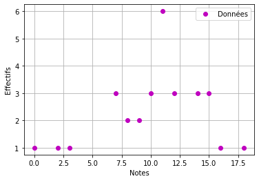

```python
from  matplotlib.pyplot import *
for i in mod :
    if(i==0) : plot(i, mod[i], 'mo', label="Données")
    else : plot(i, mod[i], 'mo')
grid(True)
xlabel("Notes")
ylabel("Effectifs")
legend()
show()
```

##### Facultatif

La fonction `scatter` de la bibliothèque `matplotlib` permet de tracer automatiquement un nuage de point. Comme le montre l'exemple suivant :

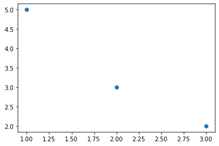

```python
scatter([1, 2, 3], [5, 3, 2])
show()
```

A l'aide de cette nouvelle fonction tracer le nuage de point du `serie1`.

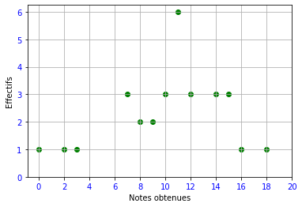

```python
X=[]
Y=[]
for x in mod :
    X.append(x)
    Y.append(mod[x])
xlabel("Notes obtenues")
ylabel("Effectifs")
scatter(X, Y,color='g')
xticks([0,2,4,6,8,10,12,14,16,18,20],  color='b')
yticks([0,1,2,3,4,5,6],  color='b')
grid(True)
show()
```

### **Le diagramme en bâton**

On trace les segments $ \displaystyle{ \Big\{\big[(x_i,n_i) ; (x_i,0)\big]\Big\}_{i\in[\![1;k]\!]}}$ où les $ x_i$ désignent les modalités et $ n_i$ les effectifs associés. Avec notre exemple cela donne :

##### Exercice

Représentez un diagramme en baton représentant le `serie1` de donnée

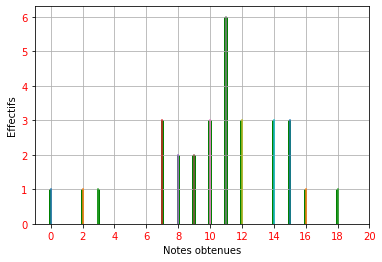

```python
import matplotlib.pyplot as plt
for x in mod :
    plt.plot([x, x], [0, mod[x]])
xlabel("Notes obtenues")
ylabel("Effectifs")
bar(X, Y, width=0.2,bottom=None,color='g')
xticks([0,2,4,6,8,10,12,14,16,18,20],  color='r')
yticks([0,1,2,3,4,5,6],  color='r')
grid(True)
show()

#plt.bar(x, y, align='center', facecolor='green', alpha=0.75)
```

##### Facultatif

Il existe un moyen de réaliser automatiquement des diagrammes en baton sous python grace à une fonction de la bibliothèque `mathplotlib`. C'est la fonction `bar` qui s'utilise comme la fonction `plot`. Observer l'exemple suivant :

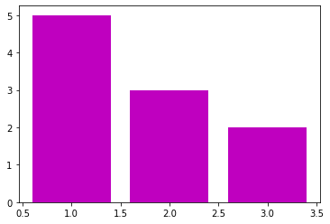

```python
bar([1, 2, 3], [5, 3, 2],color='m')
show()
```

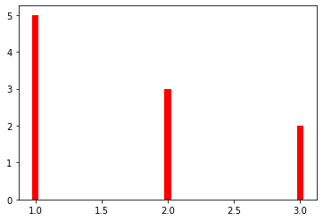

```python
bar([1, 2, 3], [5, 3, 2], width=0.05,color='r')
show()
```

### Code

A l'aide la fonction `bar` tracer le diagramme en baton du `serie1` de donnée.

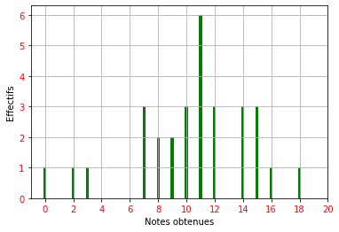

```python
X=[]
Y=[]
for x in mod :
    X.append(x)
    Y.append(mod[x])
xlabel("Notes obtenues")
ylabel("Effectifs")
bar(X, Y, width=0.2,bottom=None,color='g')
xticks([0,2,4,6,8,10,12,14,16,18,20],  color='r')
yticks([0,1,2,3,4,5,6],  color='r')
grid(True)
show()
```

### **Le diagramme à moustaches ou boite de Tukey**

Ce diagramme est un moyen rapide de figurer le profil essentiel d'une série statistique quantitative.  
Il résume les indicatuers de position (*minimum*, *maximum*, *médiane* et *quartiles*)

Ce diagramme est utilisé principalement pour comparer un même caractère dans deux populations de taille différentes.

#### Protocole de construction

1. **Tracer** un rectangle allant du premier quartile ou troisième quartile.
2. **Couper** le rectangle par la médiane.
   1. **Ajouter** des segments aux extrémités allant jusqu'au valeur extrêmes.

##### Exercice

Un directeur de supermarché décide d'étudier le temps d'attente aux caisses de son établissement pour ajuster le nombre de caisses ouverte à la demande.  
Pour cela il interroge le lundi et le vendredi cent clients et note les temps d'attente approximatifs en minutes.  
En voici les diagrammes à moustaches

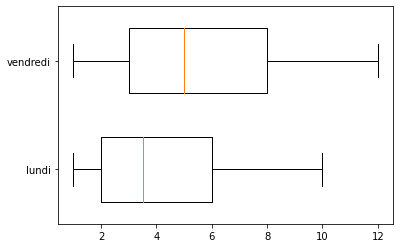

```python
from  matplotlib.pyplot import *
lun={1:14, 2:13,3:23, 4:9, 5:14, 6:8,7:12,8:4,9:1,10:2}
ven={1:5,2:9,3:12, 4:8, 5:19, 6:10,7:8,8:5,9: 11,10:9,11:2,12:2}

lundi = []
vendredi=[]
for i in lun:
    for j in range(lun[i]):
        lundi.append(i)
for i in ven:
    for j in range(ven[i]):
        vendredi.append(i)
data = [lundi,vendredi]



boxplot(lundi, positions = [1], widths = 0.6,vert=0) ;

boxplot(vendredi, positions = [2], widths = 0.6,vert=0) ;  gca().yaxis.set_ticklabels(['lundi','vendredi']) ;

show()
```

##### Facultatif

À nouveau les mêmes diagrammes un peu plus customisé.

[figure not shown]

```python
import matplotlib.pyplot as plt

def draw_plot(data, vert,edge_color, fill_color):
    bp = ax.boxplot(data,vert=False, patch_artist=True)

    for element in ['boxes', 'whiskers', 'fliers', 'means', 'medians', 'caps']:
        plt.setp(bp[element], color=edge_color)

    for patch in bp['boxes']:
        patch.set(facecolor=fill_color)

fig, ax= plt.subplots()
xlabel("Temps d'attente en minute")
draw_plot(data,1, 'red', 'tan')
y_formatter = FixedFormatter([
    "Lundi", "Mardi"])
ax.yaxis.set_major_formatter(y_formatter)
plt.show()
```

1. Comparer à l'aide des diagrammes en boîte les temps d'attente le lundi et le vendredi.
2. Dans un questionnaire, les clients qualifient d'acceptable un temps d'attente compris entr 1 et 6 minutes.

Pour chaque affirmation ci-dessous dîtes si elle est vraie ou fausse en justifiant votre réponse.

- **Affirmation A:** le vendredi, exactement la moitié des clients attendent 5 minutes ou plus en caisse.
- **Affirmation B:** le vendredi,au moins un quart des clients attendent au plus tris minutes en caisse.
- **Affirmation C:** il y a autant de clients qui trouvent le temps d'attente acceptable le lundi que le vendredi.

##### Exercice

Faire le diagramme en boite de `serie1`. Quelle conclusion pouvez vous tirez sur les notes obtenues par ce groupe à l'examen de mathématiques.

Réalisez l'exercice sur les variables en python de la fiche de suivi

Application

**Menu de navigation**

- Haut de page
- Python comme une calculatrice
- Le calcul propositionnel en python
- La puissance des boucles
- Numération sur les nombres entiers
- Numération sur les nombres décimaux
- Graphiques en python

L'objectif de cette dernière partie est de faire une analyse des résultats de la promo de l'an passé en DUTINFO selon son groupe de TD. Pour ce faire, il faut partir du fichier csv du logiciel de notes, SCODOC utilisé par les enseignants et le convertir en tableau exploitable par python grâce la libraire **Pandas**. **Pandas** permet de manipuler facilement des données à analyser :

- Manipuler des tableaux de données avec des étiquettes de variables (colonnes) et d'individus (lignes).
- ces tableaux sont appelés DataFrames, similaires aux dataframes sous R.
- on peut facilement lire et écrire ces dataframes à partir ou vers un fichier tabulé. </ul> Exécuter la cellule ci-dessous et répondre aux questions posées.
  1. Combien y-a-t-il d'étudiants dans la promotion?
  2. Quelles informations contiennent le tableau?
  3. Combien y-a-t-il de groupes différents
  4. on peut faciler tracer des graphes à partir de ces DataFrames grâce à matplotlib.

```python
import pandas as pd
```

```python
Notes=pd.read_excel("NotesButInfoanonym1.xlsx")
```

```python
Notes
```

|  | Rg | Civ. | Groupe TD | Moy | UE11 | UE12 |
| --- | --- | --- | --- | --- | --- | --- |
| 0 | 1 | M. | Whaitiri | 17.15 | 18.97 | 18.50 |
| 1 | 2 | Mme | Shango | 16.87 | 18.11 | 16.88 |
| 2 | 3 | M. | Tlaloc | 16.42 | 18.18 | 18.90 |
| 3 | 4 | M. | Whaitiri | 15.64 | 17.33 | 17.53 |
| 4 | 5 | M. | Indra | 15.59 | 17.08 | 16.64 |
| ... | ... | ... | ... | ... | ... | ... |
| 133 | 134 | M. | Indra | 2.64 | 2.33 | 3.07 |
| 134 | 135 | M. | Zeus | 0.88 | 0.04 | 0.10 |
| 135 | 136 ex | Mme | Dém. | NaN | NaN | NaN |
| 136 | 136 ex | M. | Dém. | NaN | NaN | NaN |
| 137 | 136 ex | M. | Dém. | NaN | NaN | NaN |

138 rows × 6 columns

##### Exercice

1. Quel groupe à la meilleur moyenne?
2. Est-ce le groupe le plus homogène?
3. Proposer une illustration permettant de comparer sur un seul graphique les résultats obtenus par chacun des groupes.

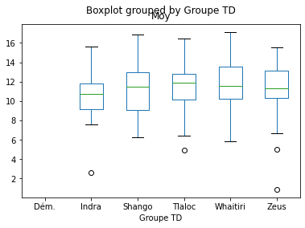

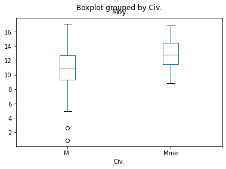

```python
Notes.boxplot(by ='Groupe TD', column =['Moy'], grid = False)
Notes.boxplot(by ='Civ.', column =['Moy'], grid = False)
```